# EFCU Member Opinion Dashboard

Members surveyed

128

Employee rating (out of 5)

4.21

Rate EFCU good or excellent

80%

Currently have an EFCU loan

45%

How members rate EFCU employees (1 = strongly disagree, 5 = strongly agree)

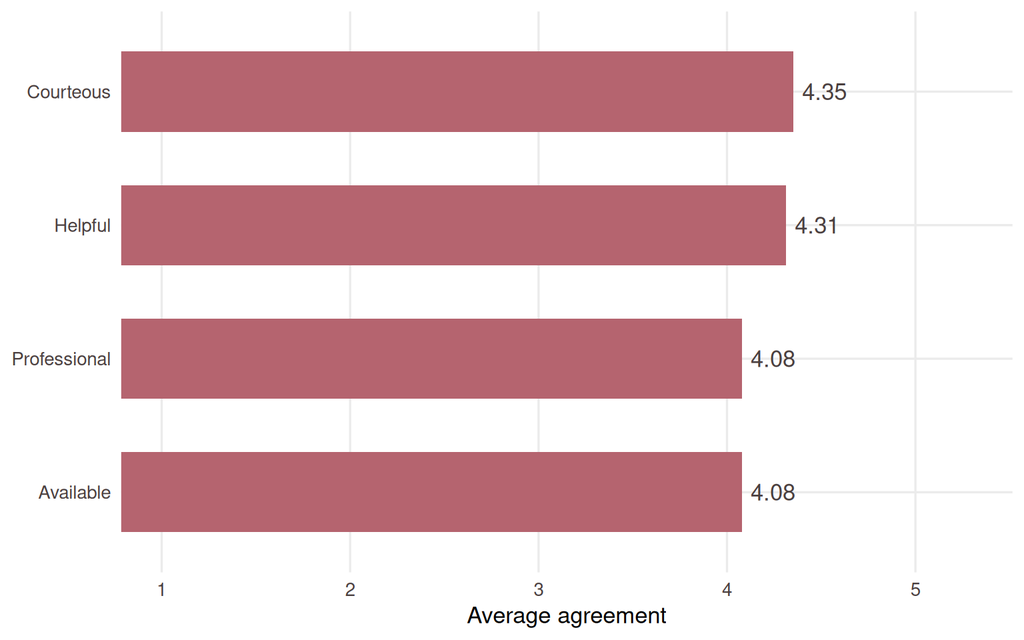

Overall rating of the credit union

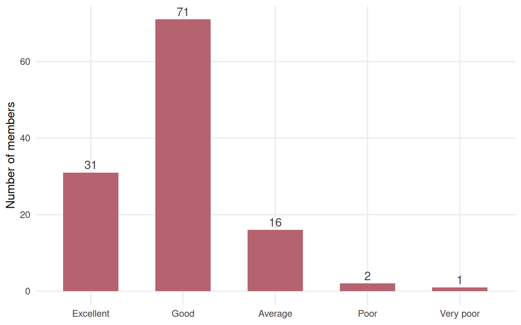

Awareness and use of EFCU services

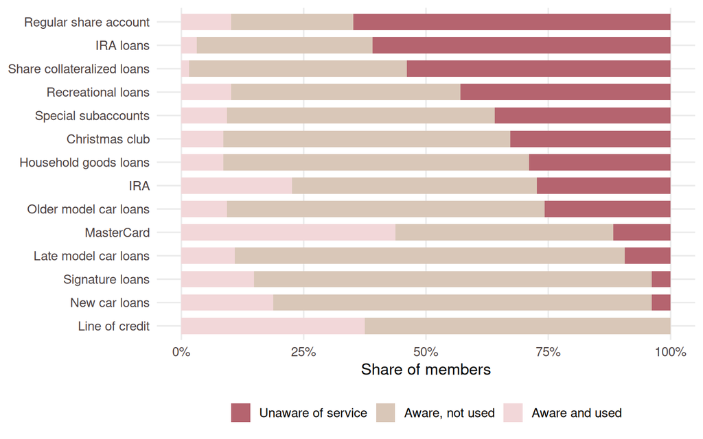

How to read this

Services near the top of the chart have the most members who did not know they existed. Those are the best candidates for member communication, since people cannot use a loan product they have never heard of.

Loan attitudes by member location (1 = strongly disagree, 5 = strongly agree)

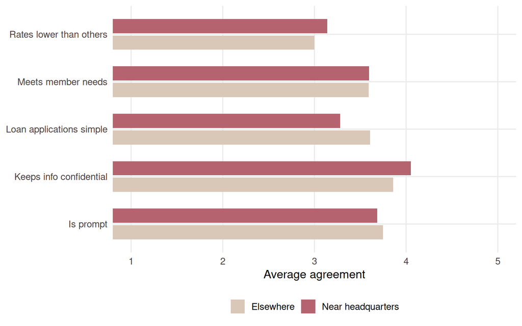

Share of members with an EFCU loan, by location

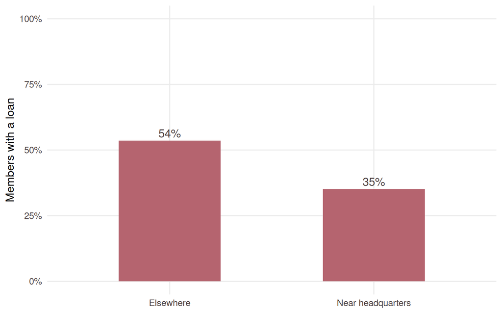

Opinion of EFCU loan rates

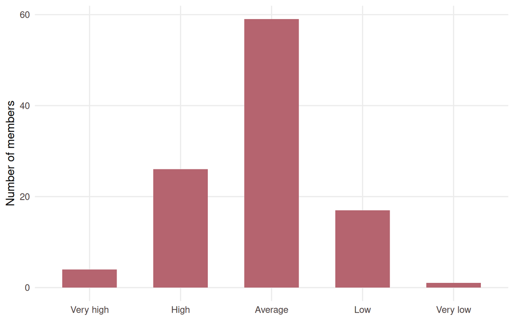

About this dashboard

**Data:** Case 31, Employees Federal Credit Union (EFCU) member opinion survey, 128 respondents. Used as practice data for the MSDM Culminating Experience Project while client data is still being collected.

**Business question:** The EFCU board wants to know why members are not borrowing from the credit union, how aware members are of its services, how they feel about employees, and whether members near headquarters feel differently from members who live elsewhere.

**Built with:** R (haven, dplyr, tidyr, ggplot2) and Quarto’s `dashboard` format.

**Note:** These are descriptive summaries only. Formal hypothesis tests come later in the course.